# Coffee Ratings

Ohad Aloni, Roni Gover, Margarita Timoshin

June 2021

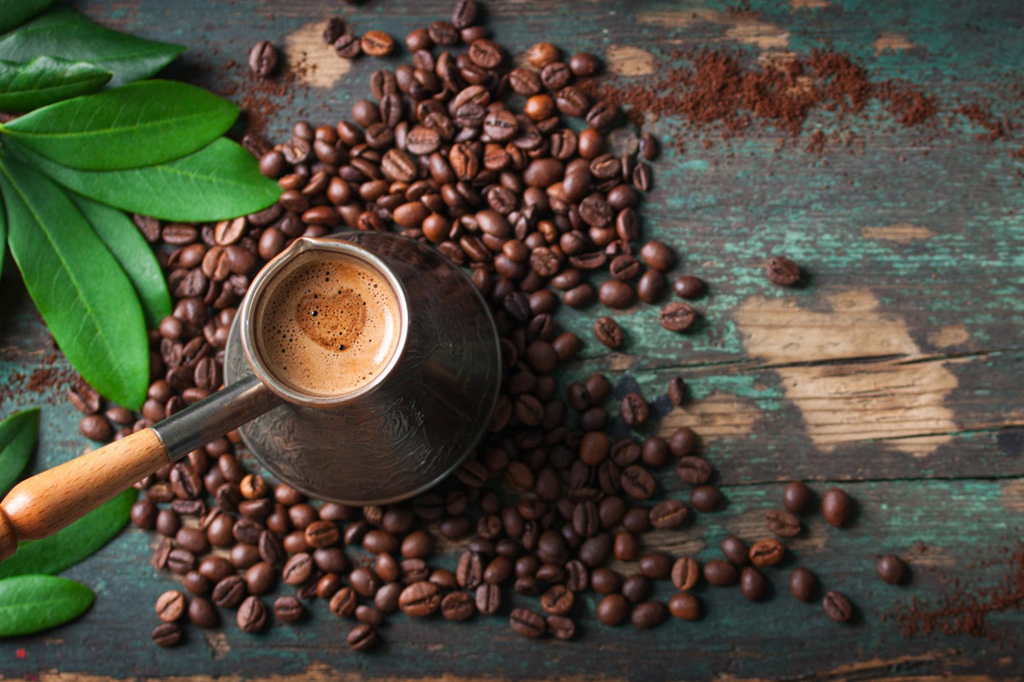

# Data Analysis

## Introduction

In this research we will focus on the Coffee Ratings data set.  
This is a sub-set of data on coffee bean ratings/quality originally collected by James LeDoux (jmzledoux) and distributed through the R for Data Science TidyTuesday project.

The data was re-posted to [Kaggle](https://www.kaggle.com/volpatto/coffee-quality-database-from-cqi?select=merged_data_cleaned.csv).

We will focus mainly on:

- Tidying our data set.
- Visualizations.
- Statistical Models and methods learned during the course.

Our goal is to demonstrate and practice the different methods which we have learned during the course by examining the relationships between different variables from our Coffee Ratings data set.

The methods used in our research are:

- Hypothesis test
- Model of simple regression.

## Importing and Tidying Data

```r
suppressWarnings(suppressMessages(library(tidyverse)))
suppressWarnings(suppressMessages(library(visdat)))
suppressWarnings(suppressMessages(library(ggplot2)))
suppressWarnings(suppressMessages(library(ggraph)))
suppressWarnings(suppressMessages(library(igraph)))
suppressWarnings(suppressMessages(library(tinytex)))
suppressWarnings(suppressMessages(library(ggridges)))
suppressWarnings(suppressMessages(library(naniar)))
suppressWarnings(suppressMessages(library(ggthemes)))
suppressWarnings(suppressMessages(library(GGally)))
suppressWarnings(suppressMessages(library(fishualize)))
suppressWarnings(suppressMessages(library(ggforce)))
suppressWarnings(suppressMessages(library(gridExtra)))
suppressWarnings(suppressMessages(library(widyr)))


coffee_ratings <- readr::read_csv('https://raw.githubusercontent.com/rfordatascience/tidytuesday/master/data/2020/2020-07-07/coffee_ratings.csv')
```

In order to get a general impression about the data, we use the function glimpse().

```r
glimpse(coffee_ratings)
```

```
## Rows: 1,339
## Columns: 43
## $ total_cup_points      <dbl> 90.58, 89.92, 89.75, 89.00, 88.83, 88.83, 88.75,~
## $ species               <chr> "Arabica", "Arabica", "Arabica", "Arabica", "Ara~
## $ owner                 <chr> "metad plc", "metad plc", "grounds for health ad~
## $ country_of_origin     <chr> "Ethiopia", "Ethiopia", "Guatemala", "Ethiopia",~
## $ farm_name             <chr> "metad plc", "metad plc", "san marcos barrancas ~
## $ lot_number            <chr> NA, NA, NA, NA, NA, NA, NA, NA, NA, NA, NA, NA, ~
## $ mill                  <chr> "metad plc", "metad plc", NA, "wolensu", "metad ~
## $ ico_number            <chr> "2014/2015", "2014/2015", NA, NA, "2014/2015", N~
## $ company               <chr> "metad agricultural developmet plc", "metad agri~
## $ altitude              <chr> "1950-2200", "1950-2200", "1600 - 1800 m", "1800~
## $ region                <chr> "guji-hambela", "guji-hambela", NA, "oromia", "g~
## $ producer              <chr> "METAD PLC", "METAD PLC", NA, "Yidnekachew Dabes~
## $ number_of_bags        <dbl> 300, 300, 5, 320, 300, 100, 100, 300, 300, 50, 3~
```

[output cut: 30 more lines]

```r
glimpse(coffee_ratings)
```

[output not shown]

[output cut: 30 more lines]

In addition, the dimension is:

```
## [1] 1339   43
```

The following table contains detailed description of table columns:

| variable | class | description |
| --- | --- | --- |
| total_cup_points | double | Total rating/points (0 - 100 scale) |
| species | character | Species of coffee bean (arabica or robusta) |
| owner | character | Owner of the farm |
| country_of_origin | character | Where the bean came from |
| farm_name | character | Name of the farm |
| lot_number | character | Lot number of the beans tested |
| mill | character | Mill where the beans were processed |
| ico_number | character | International Coffee Organization number |
| company | character | Company name |
| altitude | character | Altitude - this is a messy column |
| region | character | Region where bean came from |
| producer | character | Producer of the roasted bean |
| number_of_bags | double | Number of bags tested |
| bag_weight | character | Bag weight tested |
| in_country_partner | character | Partner for the country |
| harvest_year | character | When the beans were harvested (year) |
| grading_date | character | When the beans were graded |
| owner_1 | character | Who owns the beans |
| variety | character | Variety of the beans |
| processing_method | character | Method for processing |
| aroma | double | Aroma grade |
| flavor | double | Flavor grade |
| aftertaste | double | Aftertaste grade |
| acidity | double | Acidity grade |
| body | double | Body grade |
| balance | double | Balance grade |
| uniformity | double | Uniformity grade |
| clean_cup | double | Clean cup grade |
| sweetness | double | Sweetness grade |
| cupper_points | double | Cupper Points |
| moisture | double | Moisture Grade |
| category_one_defects | double | Category one defects (count) |
| quakers | double | quakers |
| color | character | Color of bean |
| category_two_defects | double | Category two defects (count) |
| expiration | character | Expiration date of the beans |
| certification_body | character | Who certified it |
| certification_address | character | Certification body address |
| certification_contact | character | Certification contact |
| unit_of_measurement | character | Unit of measurement |
| altitude_low_meters | double | Altitude low meters |
| altitude_high_meters | double | Altitude high meters |
| altitude_mean_meters | double | Altitude mean meters |

Overall, we can state, that the chosen data set is pretty tidy. Yet, there are several issues we encountered.  
Problems with the applied data set:

- The harvest year data is messy. There is a need to convert all years into numeric variables.
- There are different measuring systems (Kg vs. lbs) when it comes to the bag weight column.
- There was missing data and several columns with many NA values.
- Some rows had values of 0 for the entire row and some values wasn’t reasonable (such as height = 10k).

Solutions:

- The harvest year - changed for year as -dddd- numeric format
- Bag weight - unite and fixed for kg only
- missing data - filtered in case it was a low proportion of data
- the data was filtered from invalid values

### Rearranged data

We chose to rearrange the data and summarize it to the columns we will use

```r
org_data <- coffee_ratings %>%
  filter(clean_cup > 1, altitude_mean_meters < 10000)  %>%
  select(total_cup_points, aroma, flavor, aftertaste, acidity, body, balance, uniformity, clean_cup, sweetness, cupper_points,
         moisture, altitude_low_meters, altitude_high_meters, altitude_mean_meters)
```

Organized data:

```
## Rows: 1,103
## Columns: 15
## $ total_cup_points     <dbl> 90.58, 89.92, 89.75, 89.00, 88.83, 88.67, 88.42, ~
## $ aroma                <dbl> 8.67, 8.75, 8.42, 8.17, 8.25, 8.25, 8.67, 8.08, 8~
## $ flavor               <dbl> 8.83, 8.67, 8.50, 8.58, 8.50, 8.33, 8.67, 8.58, 8~
## $ aftertaste           <dbl> 8.67, 8.50, 8.42, 8.42, 8.25, 8.50, 8.58, 8.50, 8~
## $ acidity              <dbl> 8.75, 8.58, 8.42, 8.42, 8.50, 8.42, 8.42, 8.50, 8~
## $ body                 <dbl> 8.50, 8.42, 8.33, 8.50, 8.42, 8.33, 8.33, 7.67, 7~
## $ balance              <dbl> 8.42, 8.42, 8.42, 8.25, 8.33, 8.50, 8.42, 8.42, 8~
## $ uniformity           <dbl> 10.00, 10.00, 10.00, 10.00, 10.00, 10.00, 9.33, 1~
## $ clean_cup            <dbl> 10, 10, 10, 10, 10, 10, 10, 10, 10, 10, 10, 10, 1~
## $ sweetness            <dbl> 10.00, 10.00, 10.00, 10.00, 10.00, 9.33, 9.33, 10~
## $ cupper_points        <dbl> 8.75, 8.58, 9.25, 8.67, 8.58, 9.00, 8.67, 8.50, 8~
## $ moisture             <dbl> 0.12, 0.12, 0.00, 0.11, 0.12, 0.03, 0.03, 0.10, 0~
## $ altitude_low_meters  <dbl> 1950.0, 1950.0, 1600.0, 1800.0, 1950.0, 1570.0, 1~
## $ altitude_high_meters <dbl> 2200.0, 2200.0, 1800.0, 2200.0, 2200.0, 1700.0, 1~
## $ altitude_mean_meters <dbl> 2075.0, 2075.0, 1700.0, 2000.0, 2075.0, 1635.0, 1~
```

dimension:

```
## [1] 1103   15
```

## Visualizations

In the following section, we will examine the given data using different graphs and plots

### Null values distribution

First, we will check how many entries are missing in each feature. In columns where there is a very large percentage of missing values, even if the test questions are interesting, we avoid working with these feature.  
The missing entries are shown in a scale of 1-0, where 0 represents 0 percent and 1 represents 100 percent. We will also convert this table into a graph to give a visual indication

```r
##shows which feature has missing date in 0-1 ratio.

missing_data <- coffee_ratings %>%
  summarize(across(everything(),~mean(!is.na(.)))) %>%
  gather()

print.data.frame(missing_data)
```

```
##                      key     value
## 1       total_cup_points 1.0000000
## 2                species 1.0000000
## 3                  owner 0.9947722
## 4      country_of_origin 0.9992532
## 5              farm_name 0.7318895
## 6             lot_number 0.2061240
## 7                   mill 0.7647498
## 8             ico_number 0.8872293
## 9                company 0.8439134
## 10              altitude 0.8312173
## 11                region 0.9559373
## 12              producer 0.8274832
## 13        number_of_bags 1.0000000
## 14            bag_weight 1.0000000
```

[output cut: 29 more lines]

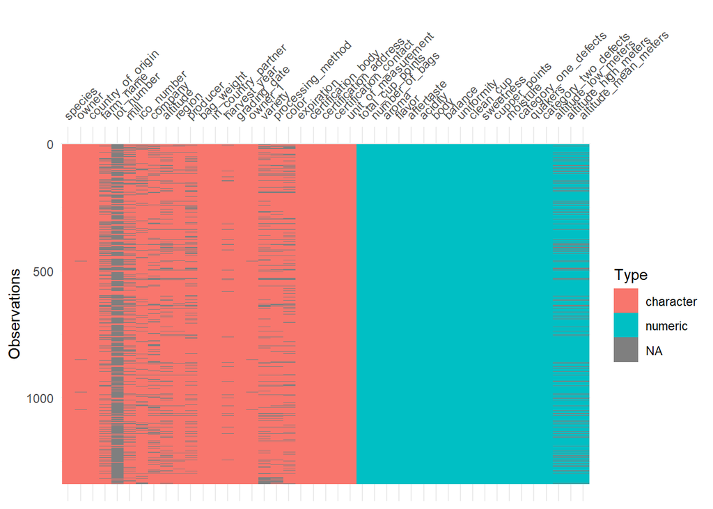

```r
visdat::vis_dat(coffee_ratings)
```

### Countries distribution

The first thing we discovered about coffee is the division into two main types sold worldwide. One is called Arabica, and as its name implies, its origins are clear, while the other - Robusta - a type of coffee that a very small percentage of the world drinks.

```r
coffee_sort <- coffee_ratings %>%
  count(species, sort = TRUE)

print.data.frame(coffee_sort)
```

```
##   species    n
## 1 Arabica 1311
## 2 Robusta   28
```

Indeed, we will look at which countries supply Arabica coffee in all its varieties in percentages. Understanding who are the major suppliers of Arabica coffee can guide test questions and hypotheses according to the contexts of the columns.  
For example, the relationship between acidity and taste, the relationship between acidity and height and more.

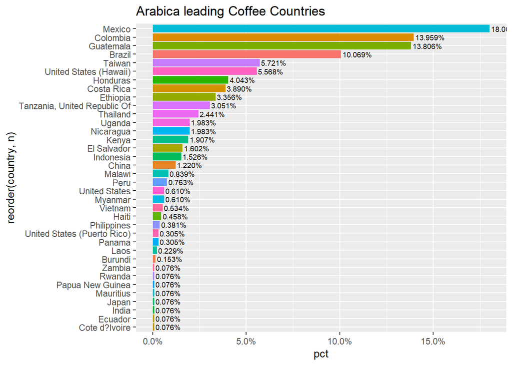

```r
arabica_countries<-coffee_ratings %>%
  filter(species =="Arabica") %>%
  count(species=factor(species),
        country=country_of_origin) %>%
  mutate(pct = prop.table(n)) %>%
  arrange(-n)

ggplot(arabica_countries %>% filter(country!="NA"),
       mapping=aes(x=reorder(country,n),y=pct,fill = country, group=1,label=scales::percent(pct))) +
  geom_bar(stat="identity")+
  geom_text(position = position_dodge(width = 0.9),
            hjust = -0.05,
            size = 2.5) +
  ggtitle("Arabica leading Coffee Countries ") +
  theme(legend.position = "none") +
  scale_y_continuous(labels = scales::percent) +
  coord_flip()
```

### Features distribution

As mentioned, the data is a ranking of coffee according to the parameters given in the tables. The total cup points column represents the rating given to the specific strain of the coffee genre tested. Thus, we found that the score column is a sum of aroma columns, acidity and more (shown in the graphs).  
Therefore, we will examine how to distribute statistically, what is the span of each parameter and more.

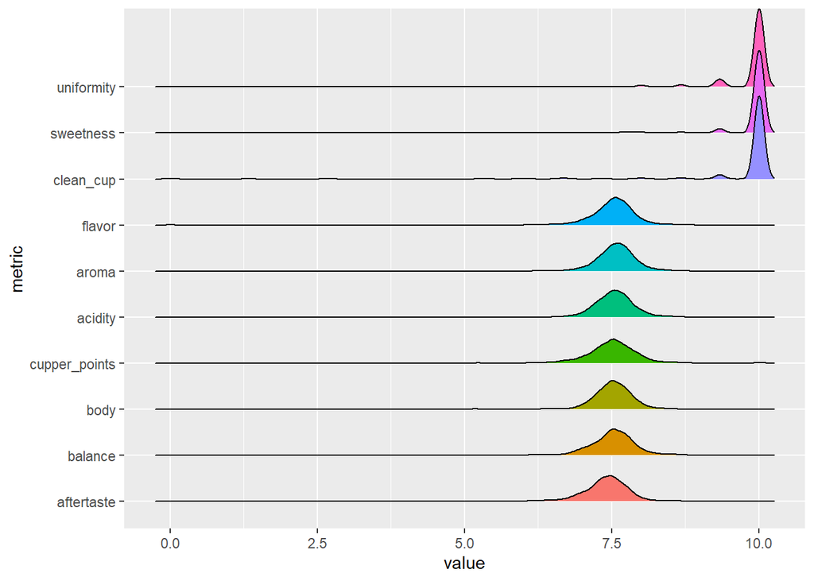

```r
coffee_metrics <- coffee_ratings %>%
  select(total_cup_points, variety, owner, company,
         country_of_origin,
         altitude_mean_meters,
         aroma:moisture) %>%
  pivot_longer(aroma:cupper_points, names_to = "metric", values_to ="value")

coffee_metrics %>%
  mutate(metric = fct_reorder(metric, value)) %>%
  ggplot(aes(value, metric,fill = metric)) +
  theme(legend.position = "none") +
  geom_density_ridges()
```

### Features correlations

Checking the correlation of the features with each other.

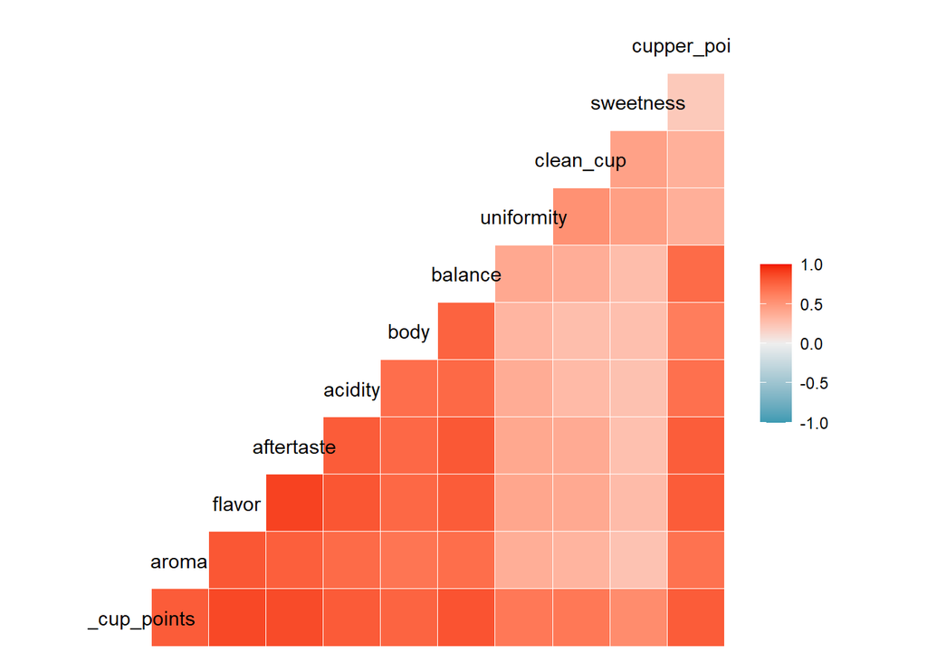

```r
coffee_ratings %>%
  select(total_cup_points, aroma:cupper_points) %>%
  ggcorr()
```

One can get the impression that most features have a mean value of 7.5 points, and look graphically normal.

### Altitude density

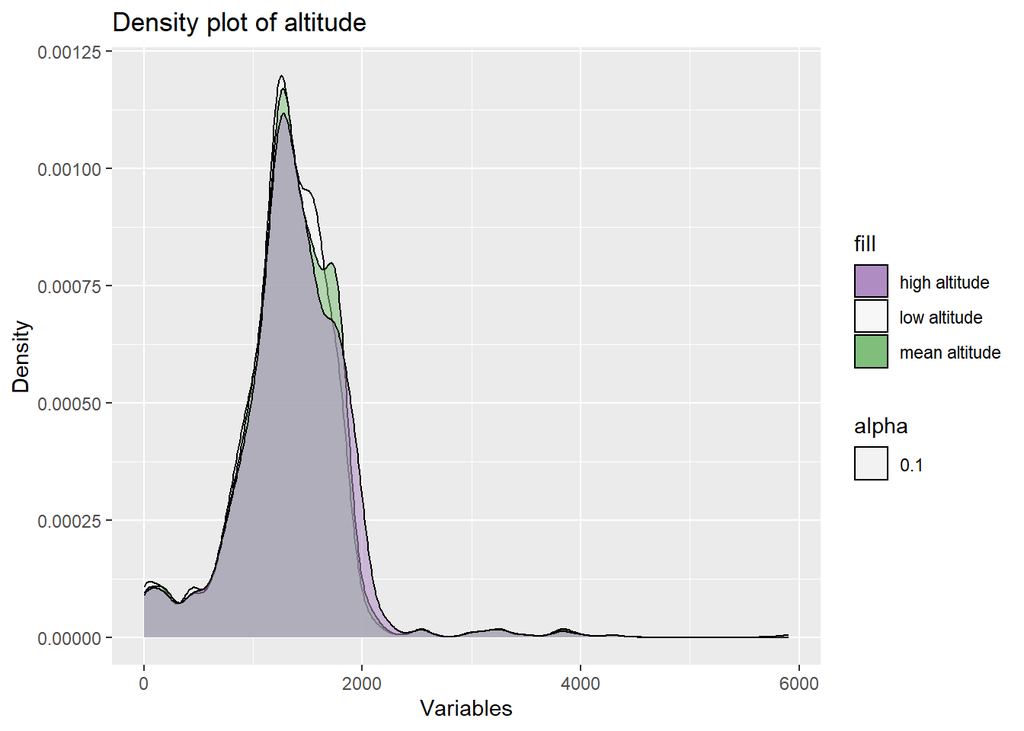

```r
height_density <- ggplot(org_data) +
  geom_density(aes(altitude_low_meters, fill ="low altitude", alpha = 0.1)) +
  geom_density(aes(altitude_mean_meters, fill ="mean altitude", alpha = 0.1)) +
  geom_density(aes(altitude_high_meters, fill ="high altitude", alpha = 0.1)) +
  scale_x_continuous(name = "Variables") +
  scale_y_continuous(name = "Density") +
  ggtitle("Density plot of altitude") +
  scale_fill_brewer(palette="PRGn")

height_density
```

The first direction we examined is the relationships to the altitude of growing coffee beans.  
First, we examined the distribution of coffee varieties according to the altitude of their growth. The division was given in the data in the form of “low altitude”, “high altitude” and “mean altitude”.  
It seems that their distribution is fairly even in terms of the amount of information for each given altitude.

### Connection between height, acidity and top 20 countries of origin

As lovers of sour coffee, we tested the mean of the acidity score according to the altitude of the beans grown and the country in which they were grown.

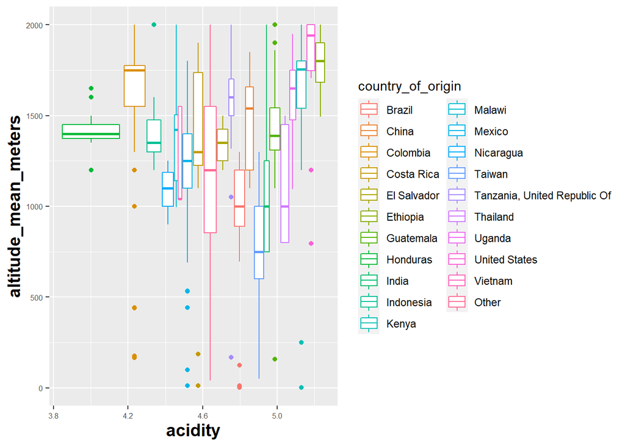

```r
coffee_ratings %>%
  filter(altitude_mean_meters < 4000) %>%
  mutate(country_of_origin = fct_lump(country_of_origin, 20), sort = TRUE) %>%
  mutate(altitude_mean_meters = pmin(altitude_mean_meters, 2000)) %>%
  ggplot(aes(x = acidity, y = altitude_mean_meters, color = country_of_origin)) +
  geom_boxplot() +
  theme(axis.text=element_text(size=6),
        axis.title=element_text(size=14,face="bold"))+
  theme(legend.position = "right")
```

## Chi Square Test

The Chi-square goodness of fit test is a statistical hypothesis test used to determine whether a variable is likely to come from a specified distribution or not.

It is often used to evaluate whether sample data is representative of the full population.  
We can assume that the acidity comes from normal distribution as there are about 1000 samples and the density graph shows a normal distribution plot. We will check our assumption by chi-square test for goodness of fit is applied.  
H0: acidity is normally distributed.  
H1: acidity is not normally distributed.

```r
interval_breaks <- c(5.2,6.75,7.08,7.25,7.42,7.58,7.75,7.92,8.08,8.25,8.33,9)

acidity_col <- org_data %>%
  mutate(score = cut(acidity, breaks = interval_breaks),include.lowest=TRUE)%>%
  select(acidity,score)

mu <- mean(acidity_col$acidity)
sigma <- sd(acidity_col$acidity)

acidity_chi_prep <- acidity_col %>%
  select(score, acidity) %>%
  count(score, name = "observed") %>%
  mutate(upper_bound = interval_breaks[-1]) %>%
  mutate(lower_bound = interval_breaks[1:11]) %>%
  mutate(expected_prob = pnorm(q = upper_bound, mean = mu, sd = sigma)-
           pnorm(q = lower_bound, mean = mu, sd = sigma)) %>%
  mutate(expected_prob = expected_prob/sum(expected_prob)) %>%
  mutate(expected = expected_prob*1103) %>%
  mutate(chi_comp = (observed-expected)^2/expected)
chi2_0 <- sum(acidity_chi_prep$chi_comp)
chi2_0
```

```
## [1] 57.18258
```

```r
qchisq(p = 1-0.05, df = 11-2-1)
```

```
## [1] 15.50731
```

57.18 = chi2_0 > qchisq = 15.50731. we reject the null hypothesis. Acidity does not distribute normal.

## Simple linear Regression

correlation between features can help when searching the perfect coffee mixture for one’s needs .  
According to the correlation graph we wanted to see if there is a linear correlation between acidity and flavor.

```r
model=lm(org_data$acidity~org_data$flavor)
summary(model)
```

```
##
## Call:
## lm(formula = org_data$acidity ~ org_data$flavor)
##
## Residuals:
##      Min       1Q   Median       3Q      Max
## -2.26551 -0.10855  0.00704  0.12193  0.82464
##
## Coefficients:
##                 Estimate Std. Error t value Pr(>|t|)
## (Intercept)      2.12993    0.14036   15.18   <2e-16 ***
## org_data$flavor  0.71808    0.01863   38.55   <2e-16 ***
## ---
## Signif. codes:  0 '***' 0.001 '**' 0.01 '*' 0.05 '.' 0.1 ' ' 1
##
## Residual standard error: 0.2044 on 1101 degrees of freedom
## Multiple R-squared:  0.5745, Adjusted R-squared:  0.5741
## F-statistic:  1486 on 1 and 1101 DF,  p-value: < 2.2e-16
```

### Linear Regression plot

We decided to perform two regressions.  
One, is to test the relationship, if do exist, between the altitude of coffee beans growth and the acidity score, and of course, as an after effect - the effect of acidity on the taste score.

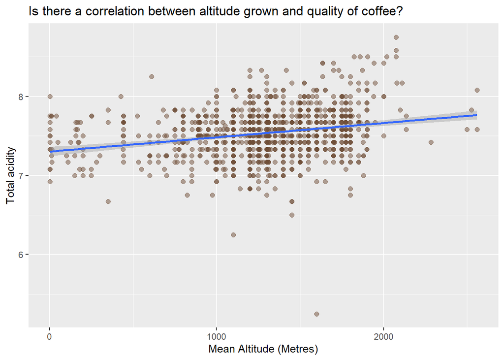

```r
coffee_ratings %>%
  filter(altitude_mean_meters < 3000, acidity > 0) %>%
  ggplot(aes(x = altitude_mean_meters, y = acidity)) +
  geom_point(colour = "#6f4e37", alpha = 0.5, size = 2) +
  geom_smooth(method = "lm") +
  labs(x = "Mean Altitude (Metres)", y = "Total acidity", title = "Is there a correlation between altitude grown and quality of coffee?")
```

```r
#THIS IS A FILLTER TABLE FOR REGRESSION WITHOUT MEAN ALTITUDE > 3000
filtered <- coffee_ratings %>%
  ggplot(aes(x = altitude_mean_meters, y = acidity)) +
  geom_point(colour = "#6f4e37", alpha = 0.5, size = 2) +
  stat_smooth(method = lm, se = FALSE) +
  geom_smooth(method = "lm") +
  labs(x = "Mean Altitude (Metres)", y = "Total acidity", title = "Is there a correlation between altitude grown and quality of coffee?")

# RUN THE LR
filtered <- coffee_ratings[which(coffee_ratings$altitude_mean_meters < 3000 & coffee_ratings$acidity > 0),]
model2=lm(filtered$acidity~filtered$altitude_mean_meters)
summary(model2)
```

```
##
## Call:
## lm(formula = filtered$acidity ~ filtered$altitude_mean_meters)
##
## Residuals:
##      Min       1Q   Median       3Q      Max
## -2.34140 -0.18943 -0.00174  0.17945  1.07282
##
## Coefficients:
##                                Estimate Std. Error t value Pr(>|t|)
## (Intercept)                   7.302e+00  2.979e-02 245.128  < 2e-16 ***
## filtered$altitude_mean_meters 1.806e-04  2.182e-05   8.276  3.7e-16 ***
## ---
## Signif. codes:  0 '***' 0.001 '**' 0.01 '*' 0.05 '.' 0.1 ' ' 1
##
## Residual standard error: 0.3015 on 1088 degrees of freedom
## Multiple R-squared:  0.05922,    Adjusted R-squared:  0.05836
## F-statistic: 68.49 on 1 and 1088 DF,  p-value: 3.696e-16
```

```r
coef(model2)
```

```
##                   (Intercept) filtered$altitude_mean_meters
##                  7.3024699594                  0.0001805814
```

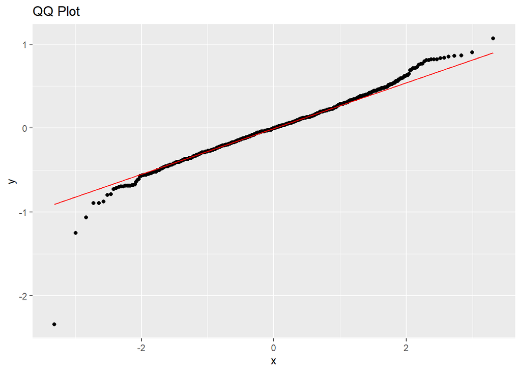

```r
### RESID QQ PLOT
resid_qq<- model2 %>% ggplot(aes(sample=.resid)) +
  geom_qq() + geom_qq_line(col="red") +
  labs(title="QQ Plot")
resid_qq
```

Therefore, it can be seen that there is a similarity or identity between the parameters according to the QQ graph, when at the edges there are outlines, i.e. edge values that are entered in incorrect data or are not representative anomalies.  
Most of the graph is on straight line, so a reasonable estimate and approximation with this information is of normal distribution  
When the two distributions that are compared are identical, the points in the Q-Q diagram will be found near the straight line y = x. If there is a linear relationship between the distributions, the points in the Q-Q diagram will be found near a straight line, but not necessarily y = x.  
The Q-Q diagram can be used as a graphical means to evaluate parameters in a family of distributions that depend on location and scale.  
Figure Q-Q is used to compare the shape of the distributions, and provides a graphical illustration of features such as location, scale, and grading of two distributions. Q-Q charts can be used to compare observational data, or theoretical distributions. The use of Q-Q charts to compare two data samples can be seen as an asymmetric way of comparing their distributions.  
A common use for Q-Q charts is to compare the distribution of data in observations to a theoretical model for distribution, and thus the fit between the distributions can be illustrated visually.

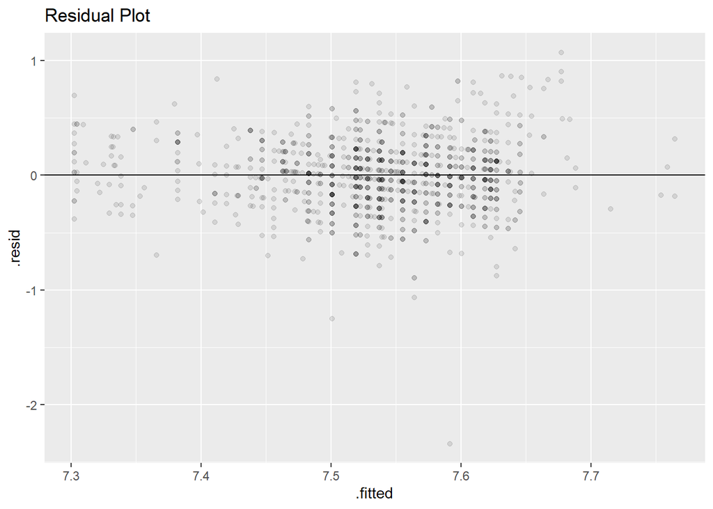

```r
### RESID  PLOT

resid_plot<- model2 %>% ggplot(aes(x=.fitted,y=.resid)) +
  geom_point(alpha=0.1) + geom_hline(yintercept=0) +
  labs(title="Residual Plot")
resid_plot
```

Heteroscedasticity means unequal scatter. In regression analysis, we talk about heteroscedasticity in the context of the residuals or error term.  
Specifically, heteroscedasticity is a systematic change in the spread of the residuals over the range of measured values. Heteroscedasticity is a problem because ordinary least squares (OLS) regression assumes that all residuals are drawn from a population that has a constant variance (homoscedasticity).  
To satisfy the regression assumptions and be able to trust the results, the residuals should have a constant variance

[figure not shown]

```r
org_data %>%
  ggplot(aes(x = acidity, y = flavor)) +
  geom_point(colour = "#6f4e37", alpha = 0.5, size = 2) +
  stat_smooth(method = lm, se = FALSE) +
  geom_smooth(method = "lm") +
  labs(x = "Flavor", y = "Acidity", title = "Is there a correlation between flavor and acidity of coffee?")
```

### Residual plot

We will check the assumption if homoscedastic is correct.

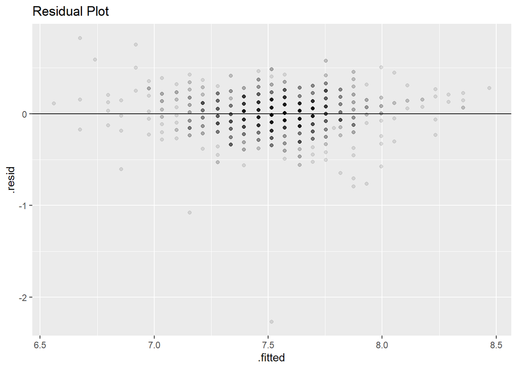

```r
resid_plot<- model %>% ggplot(aes(x=.fitted,y=.resid)) +
  geom_point(alpha=0.1) + geom_hline(yintercept=0) +
  labs(title="Residual Plot")
resid_plot
```

The residuals plot looks homoscedastic.

### QQ plot

we will check the assumption that our variables distribute normally.

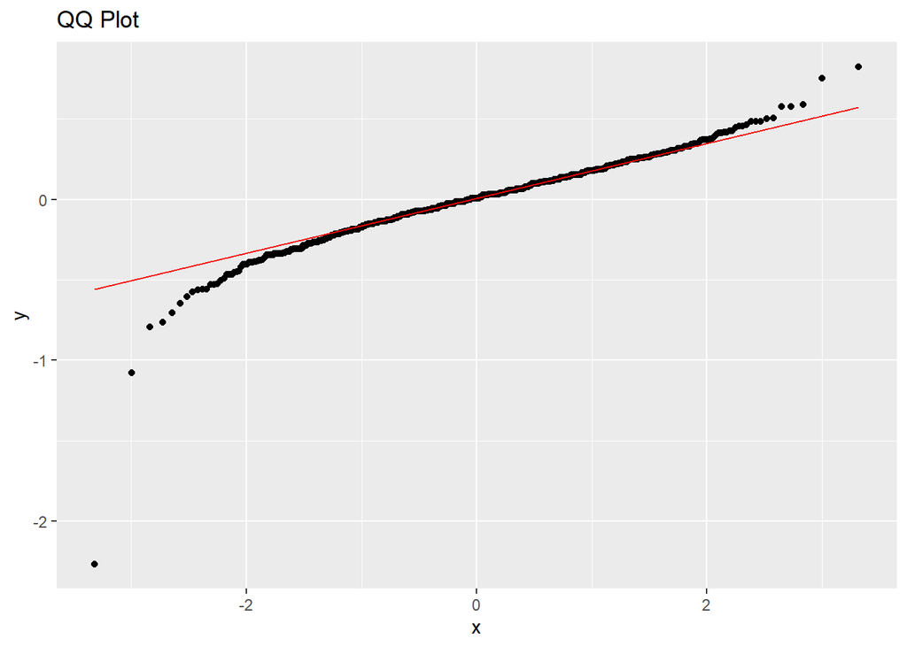

```r
resid_qq<- model %>% ggplot(aes(sample=.resid)) +
  geom_qq() + geom_qq_line(col="red") +
  labs(title="QQ Plot")
resid_qq
```

The distribution in the data isn’t going to be exactly normal. However, the Q-Q plot shows that normality is probably a reasonably good approximation.  
Given that the graph looks homoscedastic and has a tendency to normal distribution, since the R-squared is relatively high and explains more than 50 percent of the variance of flavor, it was loosely determined that acidity is a reasonable indicator of flavor prediction.

😊

[figure not shown]